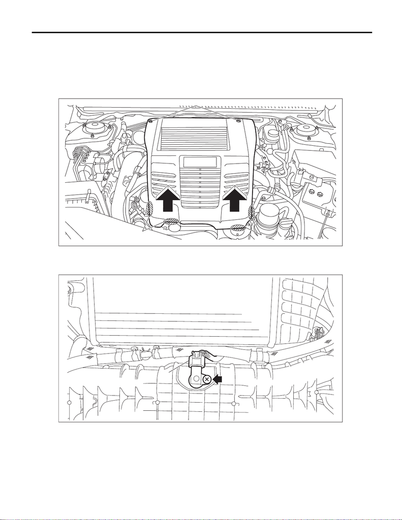

FU(w/o STI)-120

Manifold Absolute Pressure and Intake Air Temperature Sensor

FUEL INJECTION (FUEL SYSTEMS)

20.Manifold Absolute Pressure and Intake Air Temperature Sensor

A: REMOVAL

1) Remove the collector cover.

(1) Remove the clips (A).

(2) Hold the shaded area (B) by hand and carefully pull the RH side (C) upward.

(3) Hold the shaded area (D) by hand and carefully pull the LH side (E) upward.

2) Disconnect the ground terminal from battery sensor. <Ref. to NT-5, BATTERY, NOTE, Note.>

3) Disconnect the connector (A) from the manifold absolute pressure & intake air temperature sensor, and re-

move the manifold absolute pressure & intake air temperature sensor from the intake manifold.

B: INSTALLATION

Install in the reverse order of removal.

NOTE:

Use new O-rings.

Tightening torque:

3.5 N·m (0.4 kgf-m, 2.6 ft-lb)

EX-03204

(A)

(B)

(C)

(E)

(D)

FU-08337

(A)

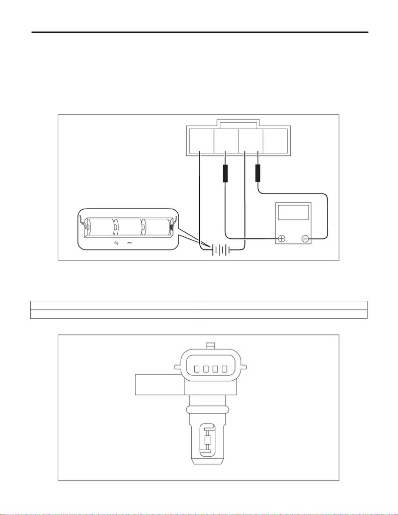

FU(w/o STI)-121

Manifold Absolute Pressure and Intake Air Temperature Sensor

FUEL INJECTION (FUEL SYSTEMS)

C: INSPECTION

1. CHECK MANIFOLD ABSOLUTE PRESSURE SENSOR

1) Connect dry-cell battery positive terminal to terminal No. 4 and dry-cell battery ground terminal to terminal

No. 2, circuit tester positive terminal to terminal No. 3 and the circuit tester ground terminal to terminal No. 2.

NOTE:

• Use new dry-cell batteries.

• Using circuit tester, check the voltage of a single dry-cell battery is 1.6 V or more. And also check the volt-

age of three batteries in series is between 4.8 V and 5.2 V.

2) Check the voltage at a normal atmospheric pressure.

NOTE:

The atmospheric pressure at higher altitude is lower than normal. Therefore, the voltage is lower than the

standard value.

3) Connect the Mighty Vac to the pressure port (A).

Terminal No. Standard

3 (+) and 2 (–) Approx. 2 V (when 25°C (77°F))

FU-07461

4 3 2 1

1.5V

1.5V

1.5V

4.8 5.2V

V

FU-07938

(A)

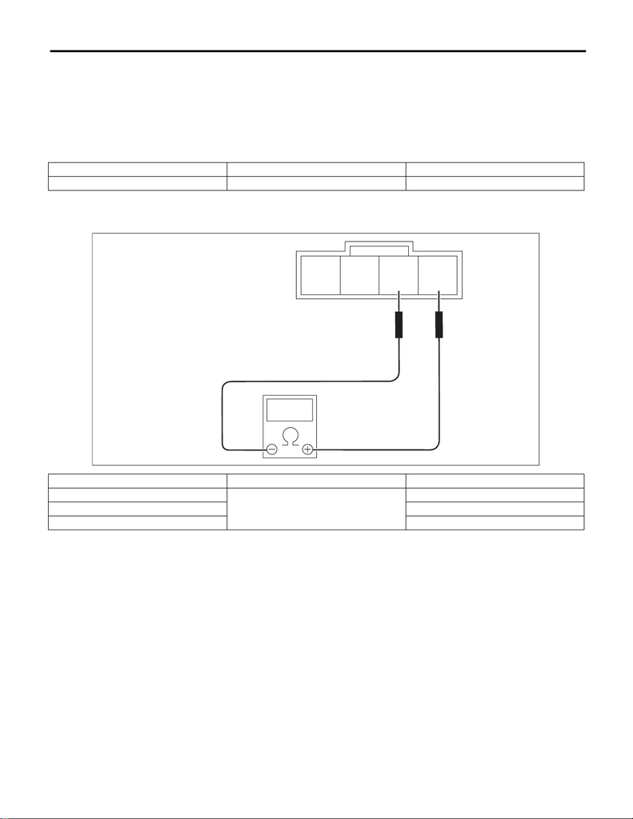

FU(w/o STI)-122

Manifold Absolute Pressure and Intake Air Temperature Sensor

FUEL INJECTION (FUEL SYSTEMS)

4) Check the voltage when generating vacuum and positive pressure using Mighty Vac.

CAUTION:

Do not apply vacuum of less than –88 kPa (–0.9 kg/cm

2

, –12.8 psi). Doing so may damage the mani-

fold absolute pressure sensor.

NOTE:

When vacuum pressure occurs at the pressure port, the voltage will drop from the value as in step 3). When

positive pressure occurs, on the other hand, the voltage will rise.

2. CHECK MANIFOLD TEMPERATURE SENSOR UNIT

3. OTHER INSPECTIONS

Check that the manifold pressure & intake air temperature sensor has no deformation, cracks or other dam-

ages.

Pressure Terminal No. Standard

–88 kPa (–0.9 kg/cm

2

, –12.8 psi) 3 (+) and 2 (–) Approx. 1 V (when 25°C (77°F))

Temperature Terminal No. Standard

–20°C (–4°F)

1 and 2

Approx. 14.7±2.2 kΩ

25°C (77°F) Approx. 2.0±0.2 kΩ

60°C (140°F) Approx. 0.59±0.09 kΩ

FU-07853

4 3 2 1